# Risk Factor Analysis

## Outcome Variable

**Outcome Variable:** whz

## Predictor Variables

**Intervention Variable:** hhwealth_quart

**Adjustment Set:**

- arm
- sex
- W_mage
- meducyrs
- feducyrs
- W_gagebrth
- W_birthwt
- W_birthlen
- W_nchldlt5
- W_parity
- delta_W_mage
- delta_meducyrs
- delta_feducyrs
- delta_W_gagebrth
- delta_W_birthwt
- delta_W_birthlen
- delta_W_nchldlt5
- delta_W_parity

## Stratifying Variables

The analysis was stratified on these variable(s):

- agecat

## Data Summary

| agecat | hhwealth_quart | n_cell | n | outcome_variable |
| --- | --- | --- | --- | --- |
| Birth | Wealth Q4 | 6727 | 26358 | whz |
| Birth | Wealth Q1 | 6378 | 26358 | whz |
| Birth | Wealth Q2 | 6318 | 26358 | whz |
| Birth | Wealth Q3 | 6935 | 26358 | whz |
| 6 months | Wealth Q4 | 8916 | 31914 | whz |
| 6 months | Wealth Q1 | 7309 | 31914 | whz |
| 6 months | Wealth Q2 | 7375 | 31914 | whz |
| 6 months | Wealth Q3 | 8314 | 31914 | whz |
| 24 months | Wealth Q4 | 5689 | 20883 | whz |
| 24 months | Wealth Q1 | 4769 | 20883 | whz |
| 24 months | Wealth Q2 | 4951 | 20883 | whz |
| 24 months | Wealth Q3 | 5474 | 20883 | whz |

The following strata were considered:

- agecat: 24 months
- agecat: 6 months
- agecat: Birth

## Methods Detail

We’re interested in the causal parameters $E[Y_a]$ for all values of $a \in \mathcal{A}$. These parameters represent the mean outcome if, possibly contrary to fact, we intervened to set all units to have $A=a$. Under the randomization and positivity assumptions, these are identified by the statistical parameters $\psi_a=E_W[E_{Y|A,W}(Y|A=a,W)]$. In addition, we’re interested in the mean of $Y$, $E[Y]$ under no intervention (the observed mean). We will estimate these parameters by using SuperLearner to fit the relevant likelihood factors – $E_{Y|A,W}(Y|A=a,W)$ and $p(A=a|W)$, and then updating our likelihood fit using a joint TMLE.

For unadjusted analyses ($W=\{\}$), initial likelihoods were estimated using Lrnr_glm to estimate the simple $E(Y|A)$ and Lrnr_mean to estimate $p(A)$. For adjusted analyses, a small library containing Lrnr_glmnet, Lrnr_xgboost, and Lrnr_mean was used.

Having estimated these parameters, we will then use the delta method to estimate relative risks and attributable risks relative to a prespecified baseline level of $A$.

# Results Detail

## Results Plots

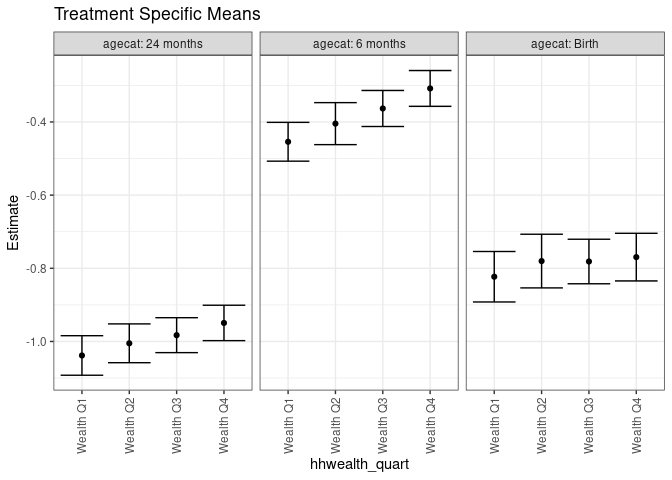

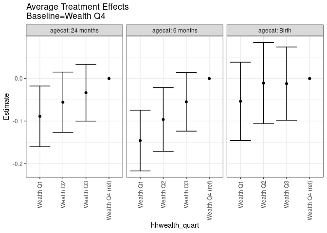

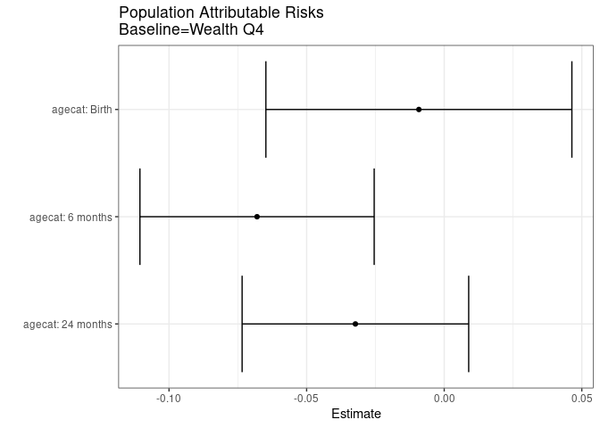

## Results Table

### Parameter: TSM

| agecat | intervention_level | baseline_level | estimate | ci_lower | ci_upper |
| --- | --- | --- | --- | --- | --- |
| Birth | Wealth Q4 | NA | -0.7694435 | -0.8345362 | -0.7043508 |
| Birth | Wealth Q1 | NA | -0.8230266 | -0.8919639 | -0.7540893 |
| Birth | Wealth Q2 | NA | -0.7802439 | -0.8536169 | -0.7068708 |
| Birth | Wealth Q3 | NA | -0.7813954 | -0.8422623 | -0.7205284 |
| 6 months | Wealth Q4 | NA | -0.3083471 | -0.3572564 | -0.2594377 |
| 6 months | Wealth Q1 | NA | -0.4541589 | -0.5071674 | -0.4011504 |
| 6 months | Wealth Q2 | NA | -0.4045555 | -0.4619278 | -0.3471832 |
| 6 months | Wealth Q3 | NA | -0.3631549 | -0.4124091 | -0.3139006 |
| 24 months | Wealth Q4 | NA | -0.9493538 | -0.9977280 | -0.9009795 |
| 24 months | Wealth Q1 | NA | -1.0382632 | -1.0922804 | -0.9842461 |
| 24 months | Wealth Q2 | NA | -1.0050108 | -1.0580522 | -0.9519693 |
| 24 months | Wealth Q3 | NA | -0.9827506 | -1.0305336 | -0.9349677 |

### Parameter: E(Y)

| agecat | intervention_level | baseline_level | estimate | ci_lower | ci_upper |
| --- | --- | --- | --- | --- | --- |
| Birth | NA | NA | -0.7786484 | -0.8112255 | -0.7460713 |
| 6 months | NA | NA | -0.3763599 | -0.4011112 | -0.3516086 |
| 24 months | NA | NA | -0.9816268 | -1.0062306 | -0.9570229 |

### Parameter: ATE

| agecat | intervention_level | baseline_level | estimate | ci_lower | ci_upper |
| --- | --- | --- | --- | --- | --- |
| Birth | Wealth Q4 | Wealth Q4 | 0.0000000 | 0.0000000 | 0.0000000 |
| Birth | Wealth Q1 | Wealth Q4 | -0.0535831 | -0.1455817 | 0.0384156 |
| Birth | Wealth Q2 | Wealth Q4 | -0.0108003 | -0.1063108 | 0.0847102 |
| Birth | Wealth Q3 | Wealth Q4 | -0.0119518 | -0.0981428 | 0.0742391 |
| 6 months | Wealth Q4 | Wealth Q4 | 0.0000000 | 0.0000000 | 0.0000000 |
| 6 months | Wealth Q1 | Wealth Q4 | -0.1458118 | -0.2172801 | -0.0743435 |
| 6 months | Wealth Q2 | Wealth Q4 | -0.0962084 | -0.1710860 | -0.0213309 |
| 6 months | Wealth Q3 | Wealth Q4 | -0.0548078 | -0.1236266 | 0.0140111 |
| 24 months | Wealth Q4 | Wealth Q4 | 0.0000000 | 0.0000000 | 0.0000000 |
| 24 months | Wealth Q1 | Wealth Q4 | -0.0889095 | -0.1601825 | -0.0176365 |
| 24 months | Wealth Q2 | Wealth Q4 | -0.0556570 | -0.1264190 | 0.0151050 |
| 24 months | Wealth Q3 | Wealth Q4 | -0.0333969 | -0.1001498 | 0.0333560 |

### Parameter: PAR

| agecat | intervention_level | baseline_level | estimate | ci_lower | ci_upper |
| --- | --- | --- | --- | --- | --- |
| Birth | Wealth Q4 | NA | -0.0092049 | -0.0648031 | 0.0463933 |
| 6 months | Wealth Q4 | NA | -0.0680128 | -0.1105736 | -0.0254521 |
| 24 months | Wealth Q4 | NA | -0.0322730 | -0.0734430 | 0.0088969 |